# Poisson regression on Adverse Event Type 2, and Adverse Event Type 3 using obsdata.csv

# 1 EXECUTIVE SUMMARY

Poisson regression models were developed for Adverse Event Type 2, and Adverse Event Type 3.

- A model was developed for Adverse Event Type 2. The analysis dataset included a total of 504 events (50.40% of study participants). The selected best exposure metric was C(ave2) (ng/mL) (p<0.0001). There was one covariate in the final model: Geographical Location.
- A model was developed for Adverse Event Type 3. The analysis dataset included a total of 312 events (31.20% of study participants). There was not a statistically significant exposure response relationship. There was one covariate in the final model: Sex.

# 2 METHODS

- If the data does not allow for a full analysis due to low incidence of an endpoint (incidence <10%), the E-R analysis for that endpoint was not conducted.
- An $\alpha$ of 0.01, which equates to a change in deviance greater than 6.63 ($\chi^2_{0.99}$), was used to identify an exposure metric for each endpoint analyzed. If no exposure metric met the $D$ criteria, the base, full, and final models did not include an exposure metric. If more than one exposure metric met the $D$ criteria, the exposure metric with the smallest p-value was selected. This is based on the rationale that smaller p-values indicate a better fit.
- Missing data within covariates was imputed provided the percentage of missing values was $\le$ 10% for continuous covariates and $\le$ 10% for categorical covariates. For continuous covariates, the median value was used for the imputed value. For categorical covariates, the mode was used for the imputed value. If the percentage of missing values was larger than the stated threshold, the covariates were excluded from consideration for the endpoint.
- The $\chi^2$ test for the log-likelihood difference in deviance between models was used to judge whether one model had a better fit over another during the backward elimination using an $\alpha$ of 0.01. When the removal of any of the remaining covariates results in a $\Delta D$ equivalent to p-value less than 0.01 the elimination process was stopped and the model was considered final. Categorical covariate would be dropped in full model development if all events occurred in only one of its categories. If any of the covariates were highly correlated (e.g. AST and ALT) with a correlation coefficient $\ge$ 0.6, then only one of the correlated covariates was tested further based on univariate Deviance.

For the full method chapter, please see https://yuchenw2015.github.io/PoissonERM

# 3 Observed Data

Table 3.1: Demographic Summaries of Categorical Covariates

| Statistics | 1 | 2 | 3 | Total |
| --- | --- | --- | --- | --- |
| N (%) | 327 (32.7) | 327 (32.7) | 346 (34.6) | 1000 (100) |
| Race |  |  |  |  |
| White | 207 (63.3) | 194 (59.3) | 214 (61.8) | 615 (61.5) |
| Black | 34 (10.4) | 32 (9.8) | 24 (6.9) | 90 (9) |
| Asian | 58 (17.7) | 61 (18.7) | 69 (19.9) | 188 (18.8) |
| Other | 28 (8.6) | 40 (12.2) | 39 (11.3) | 107 (10.7) |
| Sex |  |  |  |  |
| Male | 164 (50.2) | 163 (49.8) | 191 (55.2) | 518 (51.8) |
| Female | 163 (49.8) | 164 (50.2) | 155 (44.8) | 482 (48.2) |
| Geographical Location |  |  |  |  |
| US | 235 (71.9) | 228 (69.7) | 241 (69.7) | 704 (70.4) |
| Non-US | 92 (28.1) | 99 (30.3) | 105 (30.3) | 296 (29.6) |

Note. This table was made from an automated script. Source:Demog-Sum/Demographics-categorical.tsv

Table 3.2: Demographic Summaries of Continuous Covariates

| Statistics | 1 | 2 | 3 | Total |
| --- | --- | --- | --- | --- |
| N (%) | 327 (32.7) | 327 (32.7) | 346 (34.6) | 1000 (100) |
| age |  |  |  |  |
| Median | 45.0 | 46.0 | 45.0 | 45.0 |
| Range (Min, Max) | (14, 73) | (19, 70) | (21, 73) | (14, 73) |
| Mean (SD) | 44.8 (10.1) | 45.7 (9.0) | 45.0 (9.4) | 45.2 (9.5) |
| Missing (%) | 0 (0) | 0 (0) | 0 (0) | 0 (0) |
| Baseline Bodyweight (kg) |  |  |  |  |
| Median | 75.0 | 74.0 | 76.0 | 75.0 |
| Range (Min, Max) | (43, 101) | (41, 99) | (47, 100) | (41, 101) |
| Mean (SD) | 75.7 (10.2) | 74.5 (9.7) | 75.6 (8.9) | 75.3 (9.6) |
| Missing (%) | 0 (0) | 0 (0) | 0 (0) | 0 (0) |

Note. This table was made from an automated script. Source:Demog-Sum/Demographics-continuous.tsv

Table 3.3: Summary of Events By Endpoint

| Statistics | 1 | 2 | 3 | Total |
| --- | --- | --- | --- | --- |
| N | 327 | 327 | 346 | 1000 |
| Adverse Event Type 1 |  |  |  |  |
| Events (%) | 31 (9.5) | 10 (3.1) | 14 (4) | 55 (5.5) |
| No Events (%) | 293 (89.6) | 310 (94.8) | 326 (94.2) | 929 (92.9) |
| Missing (%) | 3 (0.9) | 7 (2.1) | 6 (1.7) | 16 (1.6) |
| Adverse Event Type 2 |  |  |  |  |
| Events (%) | 177 (54.1) | 166 (50.8) | 161 (46.5) | 504 (50.4) |
| No Events (%) | 150 (45.9) | 155 (47.4) | 177 (51.2) | 482 (48.2) |
| Missing (%) | 0 (0) | 6 (1.8) | 8 (2.3) | 14 (1.4) |
| Adverse Event Type 3 |  |  |  |  |
| Events (%) | 99 (30.3) | 98 (30) | 115 (33.2) | 312 (31.2) |
| No Events (%) | 227 (69.4) | 227 (69.4) | 227 (65.6) | 681 (68.1) |
| Missing (%) | 1 (0.3) | 2 (0.6) | 4 (1.2) | 7 (0.7) |

Note. This table was made from an automated script. Source:Demog-Sum/EventsByProtocol.tsv

Figure 3.1: Adverse Event Type 1 Exposures.

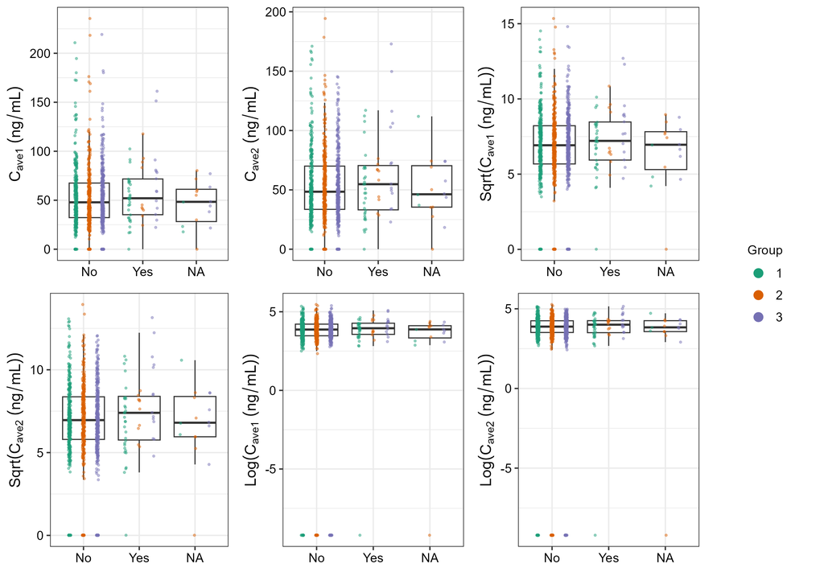

*Note.* This figure was made from an automated script. Source:Cov-EDA/Adverse-Event-Type-1-exp.png

Figure 3.2: Adverse Event Type 2 Exposures.

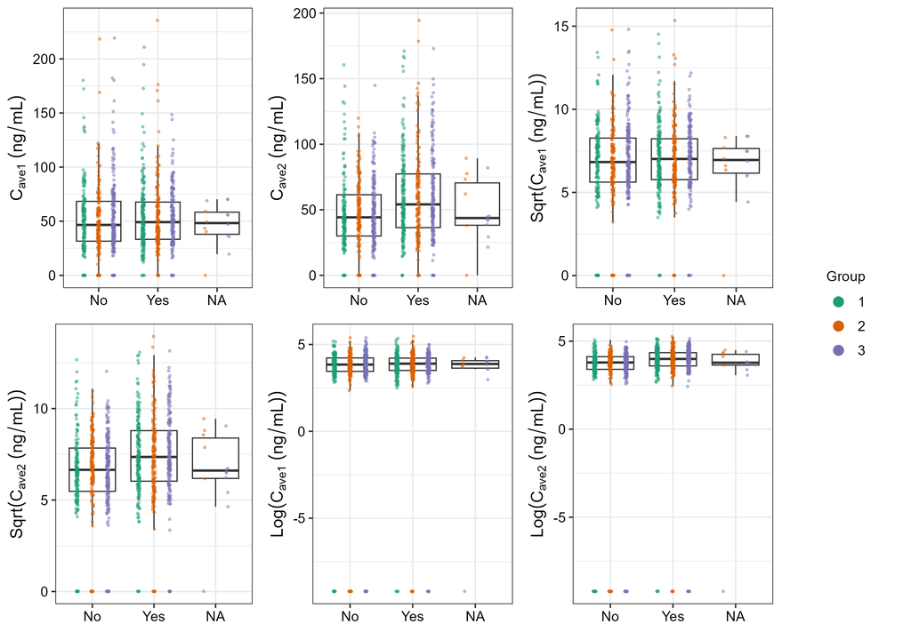

*Note.* This figure was made from an automated script. Source:Cov-EDA/Adverse-Event-Type-2-exp.png

Figure 3.3: Adverse Event Type 3 Exposures.

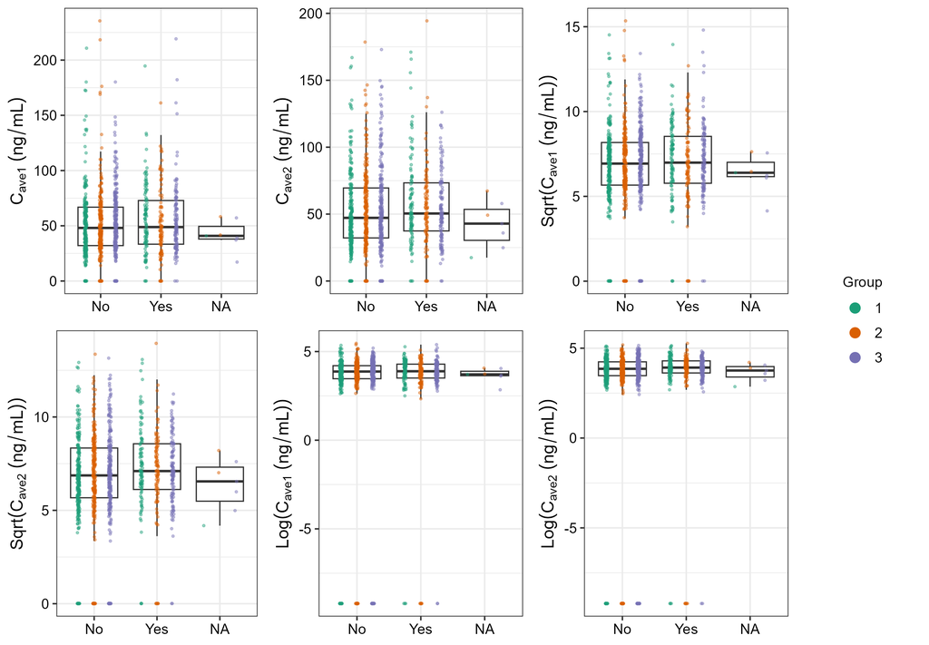

*Note.* This figure was made from an automated script. Source:Cov-EDA/Adverse-Event-Type-3-exp.png

# 4 RESULTS

## 4.1 Analysis of Adverse Event Type 2

For the model of Adverse Event Type 2, the analysis dataset included 1000 study participants. 504 of them reported events and 482 of them reported non-events.

Table 4.1: Number of Adverse Event Type 2 (First Event)

| Statistics | 1 | 2 | 3 | Total |
| --- | --- | --- | --- | --- |
| Total Number of Individuals | 327 | 327 | 346 | 1000 |
| Adverse Event Type 2 |  |  |  |  |
| Event = Yes |  |  |  |  |
| SubType 1 | 45 | 45 | 37 |  |
| SubType 2 | 48 | 39 | 44 |  |
| SubType 3 | 48 | 43 | 29 |  |
| SubType 4 | 36 | 39 | 51 |  |
| Event = No |  |  |  |  |
| SubType 5 | 74 | 79 | 90 |  |
| SubType 6 | 76 | 76 | 87 |  |
| Missing (%) | 0 (0) | 6 (1.8) | 8 (2.3) | 14 (1.4) |

Note. Percentage values refer to the number of patients. Source:Demog-Sum/Model_EventsByProtocol_endpoints_2.tsv

Table 4.2: Assessment of Exposure Metrics for Adverse Event Type 2

| Parameters | Estimate | Deviance | Null Deviance | $\Delta$D | AIC | pvalue |
| --- | --- | --- | --- | --- | --- | --- |
| C(ave1) (ng/mL) | 0.0008858 | 825.707 | 826.123 | -0.416 | 1837.707 | 0.5163 |
| C(ave2) (ng/mL) | 0.0060000 | 806.159 | 826.123 | -19.964 | 1818.159 | <0.0001 |
| Sqrt(C(ave1) (ng/mL)) | 0.0235000 | 824.537 | 826.123 | -1.586 | 1836.537 | 0.2100 |
| Sqrt(C(ave2) (ng/mL)) | 0.0850000 | 806.728 | 826.123 | -19.395 | 1818.728 | <0.0001 |
| Log(C(ave1) (ng/mL)) | 0.0362000 | 821.812 | 826.123 | -4.311 | 1833.812 | 0.0534 |
| Log(C(ave2) (ng/mL)) | 0.0521000 | 818.162 | 826.123 | -7.961 | 1830.162 | 0.0112 |

Note. Each was assessed using a base model. The user specified the significance level to be p = 0.01 for selection. Source:Adverse-Event-Type-2/Models/ExposureFit.tsv

Table 4.3: Estimates from the Base Model for Adverse Event Type 2

Effects

Estimate

95% CI

z value

Pr(>|z|)

Risk Ratio

95% CI of Risk Ratio

(Intercept)

-6.3

(-6.48, -6.13)

-69.3

<0.001

C(ave2) (ng/mL)

0.00605

(0.00344, 0.0086)

4.6

<0.001

1.01

(1, 1.01)

n

N

$\Delta$D

df

Pr(>Chisq)

LogLik

AIC

986

1000

19.96

1

<0.001

-907.08

1818.16

Note. Confidence Intervals calculated based the log-likelihood function (profile confidence interval). n = Number  
of participants with event outcomes recorded. N = Total number of participants in the study. Source:Adverse-Event-Type-2/Models/BaseModelParamSummary.tsv

Table 4.4: Incidence of Adverse Event Type 2 per 100 Patient Years

| Group | C(ave2) (ng/mL) | Cumulative Incidence per 100 Patient Years (Mean [95% CI]) |
| --- | --- | --- |
| 30 mg once daily | 25.2 | 77.9 (68.7, 88.4) |
| 50 mg once daily | 50.1 | 90.6 (82.7, 99.2) |
| 100 mg once daily | 101.0 | 123 (108, 141) |

Note. Predicted exposure metric values for each dose are derived from 2,500 simulated subjects. Source:Adverse-Event-Type-2/Prediction/mod_pred.tsv

Figure 4.1: Incidence of Adverse Event Type 2 per 100 Patient Years.

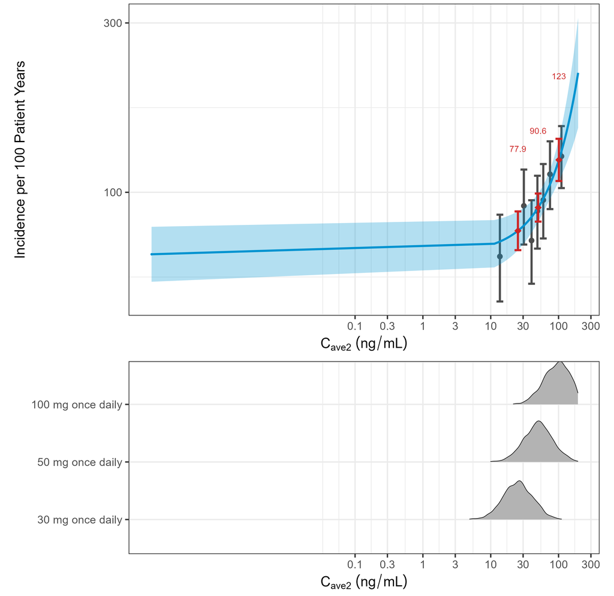

*Note.* Top: Gray circles and error bars are the observed mean and 95% CI, respectively, of the incidence of Adverse Event Type 2 (all types) per 100 patient years for each bin of the shown exposure metric in the analysis population (n of bins = 7). The blue line, (and blue shaded area) are the model-predicted mean (and 95% CI) incidence per 100 patient years for the range of observed exposure metric in the analysis population. Red circles and error bars are the model-predicted mean and 95% CI, respectively, incidence of Adverse Event Type 2 per 100 patient years. Bottom: Predicted exposure metric values for each dose are derived from 2,500 simulated subjects. Source:Adverse-Event-Type-2/Prediction/model_prediction.png

Table 4.5: Estimates from the Final Model for Adverse Event Type 2

Effects

Estimate

95% CI

z value

Pr(>|z|)

Risk Ratio

95% CI of Risk Ratio

(Intercept)

-6.54

(-6.73, -6.34)

-66.7

<0.001

Geographical Location Non-US

0.673

(0.496, 0.848)

7.49

<0.001

1.96

(1.64, 2.34)

C(ave2) (ng/mL)

0.00595

(0.00336, 0.00847)

4.56

<0.001

1.01

(1, 1.01)

n

N

$\Delta$D

df

Pr(>Chisq)

LogLik

AIC

986

1000

73.44

2

<0.001

-880.34

1766.68

Note. Confidence Intervals calculated based on the log-likelihood function (profile confidence interval). n = Number  
of participants with event outcomes recorded. N = Total number of participants in the study. Source:Adverse-Event-Type-2/Models/FinalModelParamSummary.tsv

Figure 4.2: Risk Ratio for Adverse Event Type 2.

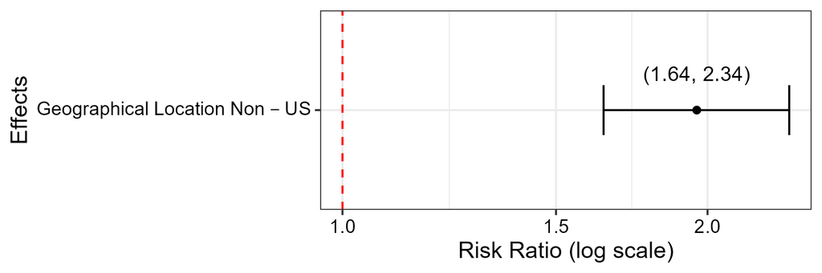

*Note.* 95% confidence intervals are presented with the estimate. Source:Adverse-Event-Type-2/OR/Adverse-Event-Type-2-odds.png

Table 4.6: Risk Ratio for Covariates in First Incidence of Adverse Event Type 2

| Variable | Risk Ratio | 95% Confidence Interval |
| --- | --- | --- |
| Geographical Location Non-US ref. to US | 1.96 | (1.64 2.34) |

Note. Risk Ratio of scenarios based on final model. 95% confidence intervals are presented with the estimate. The values in each continuous covariate are 25th and 75th percentile. Source:Adverse-Event-Type-2/OR/OR_table.tsv

## 4.2 Analysis of Adverse Event Type 3

For the model of Adverse Event Type 3, the analysis dataset included 1000 study participants. 312 of them reported events and 681 of them reported non-events.

Table 4.7: Number of Adverse Event Type 3 (First Event)

| Statistics | 1 | 2 | 3 | Total |
| --- | --- | --- | --- | --- |
| Total Number of Individuals | 327 | 327 | 346 | 1000 |
| Adverse Event Type 3 |  |  |  |  |
| Event = Yes |  |  |  |  |
| Severe | 47 | 46 | 54 |  |
| Moderate | 52 | 52 | 61 |  |
| Event = No |  |  |  |  |
| Mild | 109 | 118 | 123 |  |
| None | 118 | 109 | 104 |  |
| Missing (%) | 1 (0.3) | 2 (0.6) | 4 (1.2) | 7 (0.7) |

Note. Percentage values refer to the number of patients. Source:Demog-Sum/Model_EventsByProtocol_endpoints_3.tsv

Table 4.8: Assessment of Exposure Metrics for Adverse Event Type 3

| Parameters | Estimate | Deviance | Null Deviance | $\Delta$D | AIC | pvalue |
| --- | --- | --- | --- | --- | --- | --- |
| C(ave1) (ng/mL) | 0.0019 | 841.205 | 842.444 | -1.239 | 1469.205 | 0.2584 |
| C(ave2) (ng/mL) | 0.0027 | 840.093 | 842.444 | -2.351 | 1468.093 | 0.1203 |
| Sqrt(C(ave1) (ng/mL)) | 0.0307 | 840.777 | 842.444 | -1.667 | 1468.777 | 0.1993 |
| Sqrt(C(ave2) (ng/mL)) | 0.0454 | 838.895 | 842.444 | -3.549 | 1466.895 | 0.0625 |
| Log(C(ave1) (ng/mL)) | 0.0305 | 840.452 | 842.444 | -1.992 | 1468.452 | 0.1841 |
| Log(C(ave2) (ng/mL)) | 0.0360 | 839.782 | 842.444 | -2.662 | 1467.782 | 0.1291 |

Note. Each was assessed using a base model. The user specified the significance level to be p = 0.01 for selection. Source:Adverse-Event-Type-3/Models/ExposureFit.tsv

Table 4.9: Estimates from the Base Model for Adverse Event Type 3

| Effects | Estimate | 95% CI | z value | Pr(>\|z\|) | Risk Ratio | 95% CI of Risk Ratio |
| --- | --- | --- | --- | --- | --- | --- |
| (Intercept) | -6.44 | (-6.56, -6.34) | -114 | <0.001 | 0.00159 | (0.00142, 0.00177) |
| n | N | $\Delta$D | df | Pr(>Chisq) | LogLik | AIC |
| 993 | 1000 | 0.00 | 0 | 1.0000 | -733.22 | 1468.44 |

Note. Confidence Intervals calculated based the log-likelihood function (profile confidence interval). n = Number of participants with event outcomes recorded. N = Total number of participants in the study. Source:Adverse-Event-Type-3/Models/BaseModelParamSummary.tsv

Figure 4.3: Incidence of Adverse Event Type 3 per 100 Patient Years.

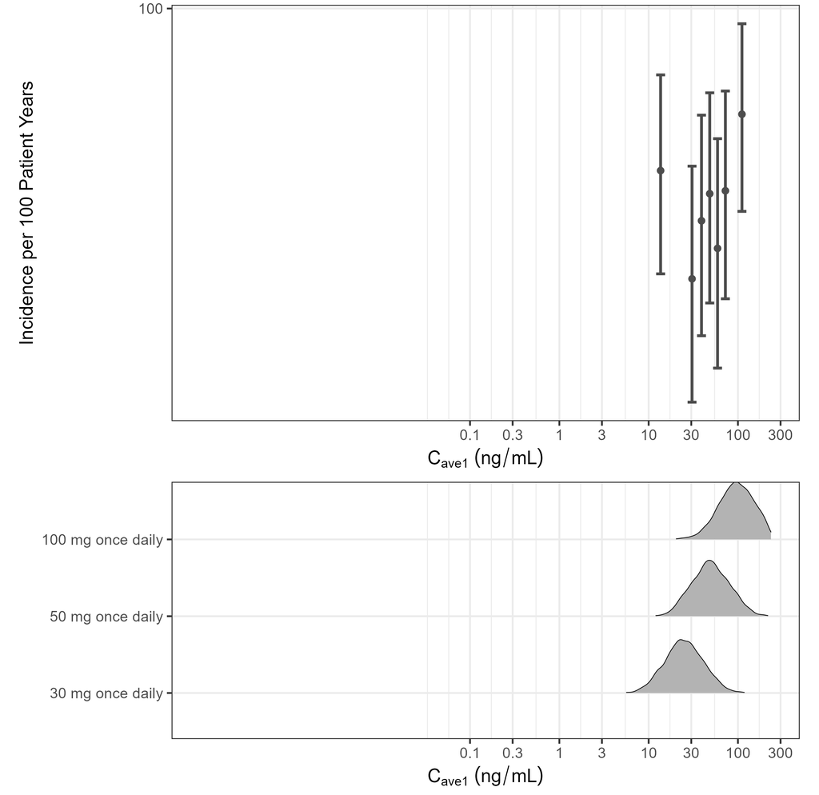

*Note.* Top: Gray circles and error bars are the observed mean and 95% CI, respectively, of the incidence of Adverse Event Type 3 (all types) per 100 patient years for each bin of the shown exposure metric in the analysis population (n of bins = 7). Bottom: Predicted exposure metric values for each dose are derived from 2,500 simulated subjects. Source:Adverse-Event-Type-3/Prediction/model_prediction.png

Table 4.10: Estimates from the Final Model for Adverse Event Type 3

Effects

Estimate

95% CI

z value

Pr(>|z|)

Risk Ratio

95% CI of Risk Ratio

(Intercept)

-6.72

(-6.91, -6.55)

-74

<0.001

Sex Female

0.506

(0.28, 0.736)

4.35

<0.001

1.66

(1.32, 2.09)

n

N

$\Delta$D

df

Pr(>Chisq)

LogLik

AIC

993

1000

19.47

1

<0.001

-723.49

1450.98

Note. Confidence Intervals calculated based on the log-likelihood function (profile confidence interval). n = Number  
of participants with event outcomes recorded. N = Total number of participants in the study. Source:Adverse-Event-Type-3/Models/FinalModelParamSummary.tsv

Figure 4.4: Risk Ratio for Adverse Event Type 3.

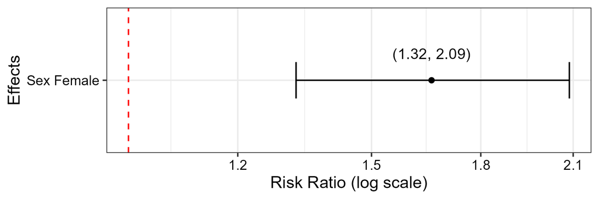

*Note.* 95% confidence intervals are presented with the estimate. Source:Adverse-Event-Type-3/OR/Adverse-Event-Type-3-odds.png

Table 4.11: Risk Ratio for Covariates in First Incidence of Adverse Event Type 3

| Variable | Risk Ratio | 95% Confidence Interval |
| --- | --- | --- |
| Sex Female ref. to Male | 1.66 | (1.32 2.09) |

Note. Risk Ratio of scenarios based on final model. 95% confidence intervals are presented with the estimate. The values in each continuous covariate are 25th and 75th percentile. Source:Adverse-Event-Type-3/OR/OR_table.tsv

# 5 CONCLUSION

- A Poisson regression model was developed for Adverse Event Type 2.
  - The selected best exposure metric was C(ave2) (ng/mL) (p<0.0001).
  - For the model of Adverse Event Type 2, the analysis dataset included 1000 study participants. 504 of them reported events and 482 of them reported non-events.
  - There was one covariate in the final model: Geographical Location.
  - The covariate Geographical Location, with the reference level of Geographical Location US, resulted in a statistically significant improvement in the model fit. The risk ratios and 95% confidence intervals for Geographical Location Non-US are 1.96 (1.64, 2.34), respectively.
- A Poisson regression model was developed for Adverse Event Type 3.
  - There was not a statistically significant exposure response relationship.
  - For the model of Adverse Event Type 3, the analysis dataset included 1000 study participants. 312 of them reported events and 681 of them reported non-events.
  - There was one covariate in the final model: Sex.
  - The covariate Sex, with the reference level of Sex Male, resulted in a statistically significant improvement in the model fit. The risk ratios and 95% confidence intervals for Sex Female are 1.66 (1.32, 2.09), respectively.

# 6 Reference

This analysis was conducted using PoissonERM package.

See more details here: https://yuchenw2015.github.io/PoissonERM-QuickStart.